# lab-07-simpsons.Rmd

batool abbas alsadah

17 March 2021

## Packages

```r
library(tidyverse)
library(mosaicData)
```

## Exercises

```r
?Whickham
```

Your answer:the data is observational as the description states that is based on age, smoking, and mortality,which are all observable events and not produced vio experiments.

```r
nrow(Whickham)
```

```
## [1] 1314
```

Your answer; Your answer; There ane 1,314 observations. As we know every row is an observation. 3.

```r
names(Whickham)
```

```
## [1] "outcome" "smoker"  "age"
```

Your answer: There are 3 variables, “outcome” “smoker”, and “age”

```r
unique(Whickham$outcome)
```

```
## [1] Alive Dead
## Levels: Alive Dead
```

```r
unique(Whickham$smoker)
```

```
## [1] Yes No
## Levels: No Yes
```

```r
unique(Whickham$age)
```

```
##  [1] 23 18 71 67 64 38 45 76 28 27 34 20 72 48 66 30 33 68 61 43 47 22 39 80 59
## [26] 56 62 51 32 60 37 36 50 55 73 52 25 53 31 54 69 79 75 21 29 24 26 49 84 40
## [51] 44 74 46 35 77 57 42 81 19 63 78 83 82 70 58 41 65
```

Your answer: using the ‘unique()’ function on the 3 variables we cloud see that “outcome” only takes alive or dead value, which makes it categorical non-ordinal. “smoker” only takes yes or no, which also makes it categorical non-ordinal. age is numerical continous data. continous one of the best ways to visualise categorical data is through the use ofbar charts.

one of the best ways to visualise categorical data is throughthe use ofbar charts.

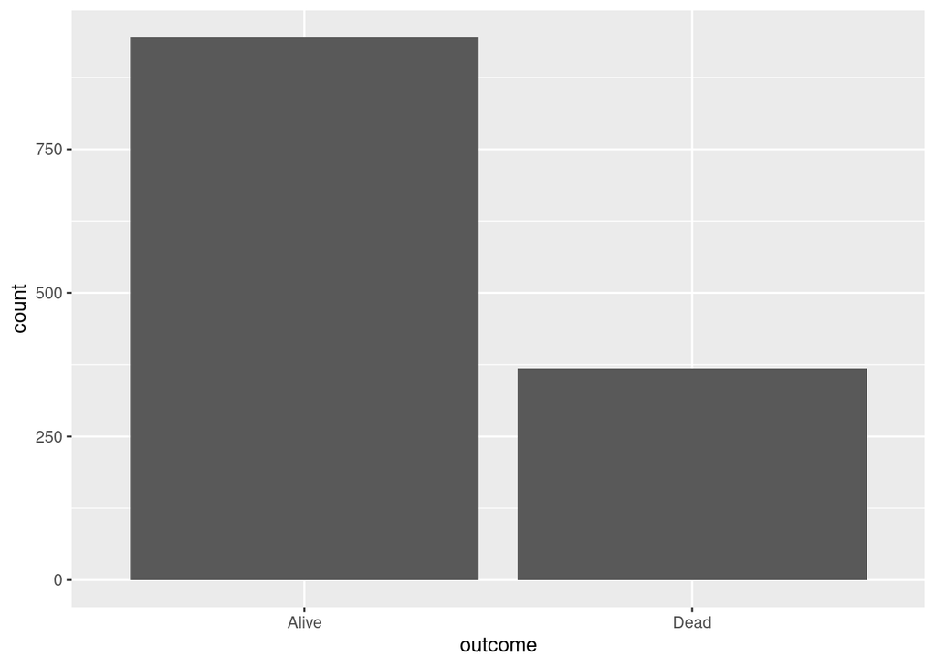

```r
ggplot(Whickham, aes(x = outcome)) +
  geom_bar()
```

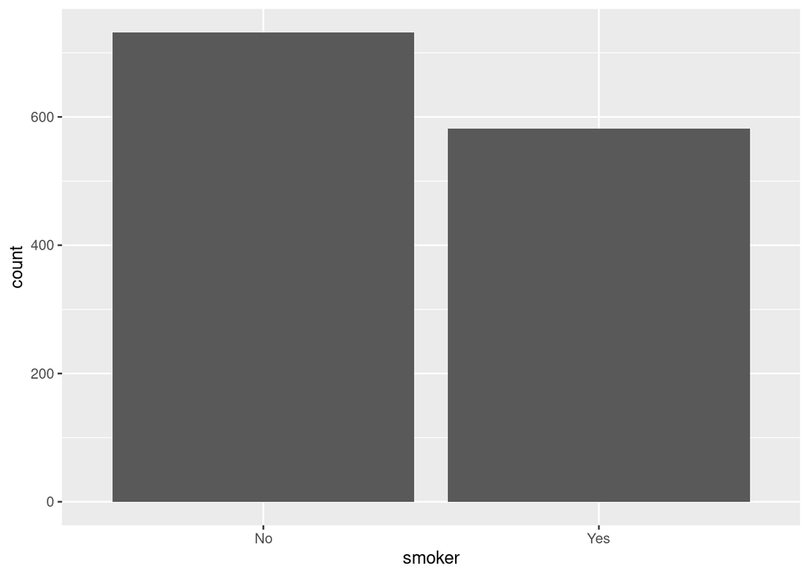

```r
ggplot(Whickham, aes(x = smoker)) +
  geom_bar()
```

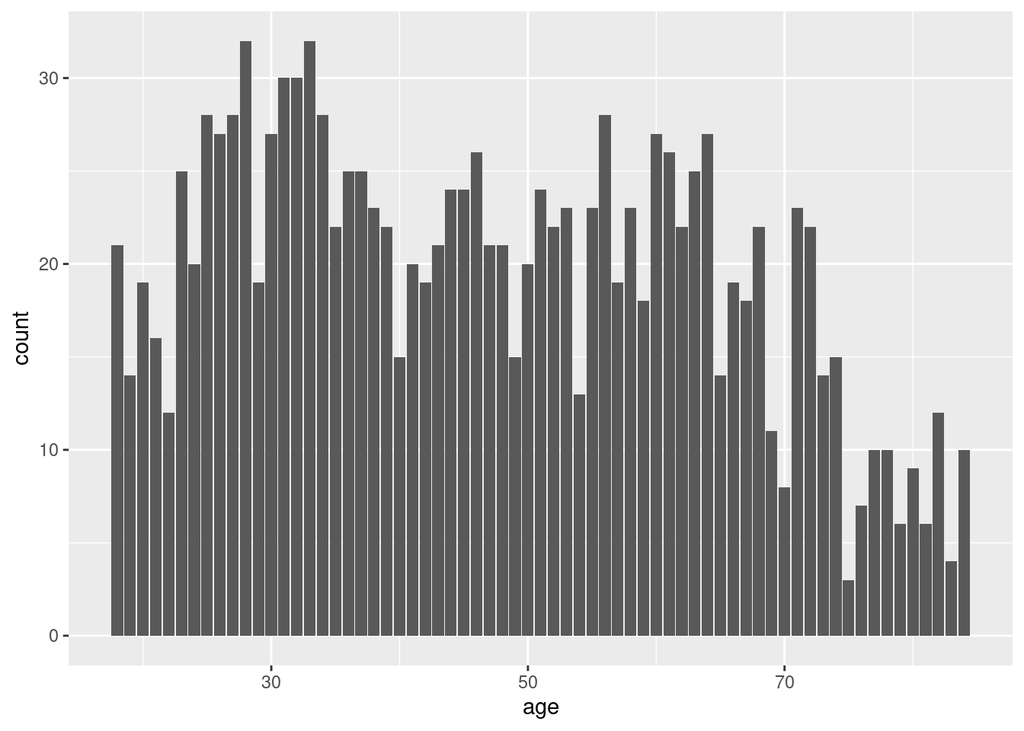

```r
ggplot(Whickham, aes(x = age)) +
  geom_bar()
```

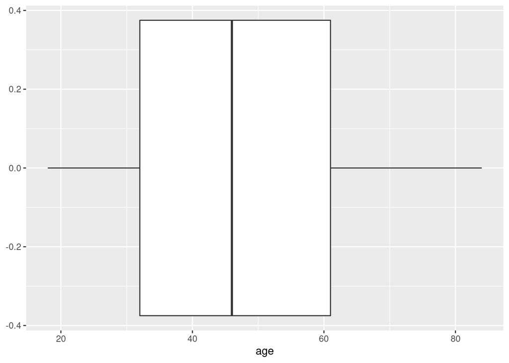

```r
ggplot (Whickham, aes(x = age)) + geom_boxplot()
```

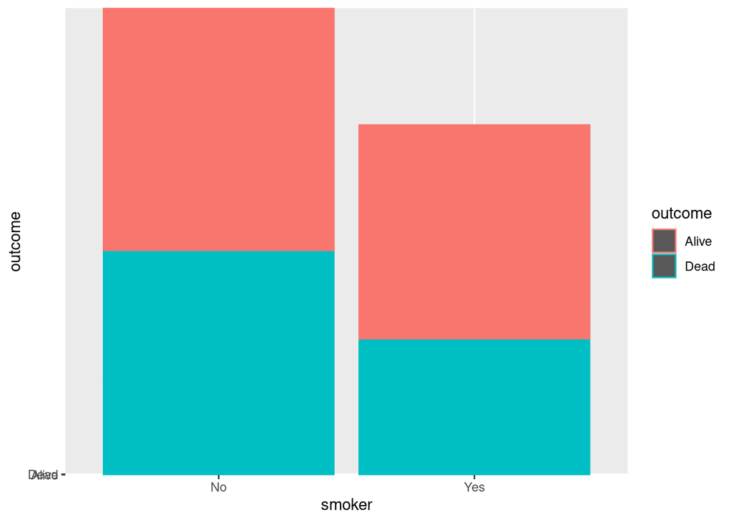

```r
ggplot(data=Whickham, aes(x=smoker, y=outcome, color=outcome)) + geom_bar(stat="identity")
```

Knit, commit, and push to github.

```r
Whickham %>%
  count(smoker, outcome)
```

| smoker | outcome | n |
| --- | --- | --- |
| No | Alive | 502 |
| No | Dead | 230 |
| Yes | Alive | 443 |
| Yes | Dead | 139 |

answer: Number of non-smokers who dovo were more than smokers

```r
Whickham <- Whickham%>% mutate (age_cat = case_when (age <= 44 ~ "18-44", age > 44. & age <= 64 ~ "45-64", age > 64 ~ "65+"))
```

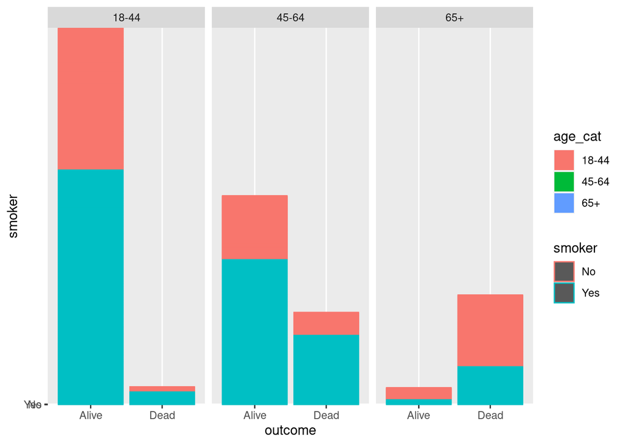

```r
ggplot(data=Whickham, aes(x=outcome, y=smoker,color=smoker, fill=age_cat)) + geom_bar(stat="identity") +facet_wrap(~age_cat)
```

[output not shown]